# Pneumonia Diagnosis

The task is to predict if a person has pneumonia or not using Chest X-Ray.

We will train a Convolutional Neural Network (CNN) that is able to detect whether a patient has pneumonia, both bacterial and viral, based on an X-ray image of their chest. We need to classify a patient as either having pneumonia or not having pneumonia. This is a binary classification problem.

**Credits**: Kaggle (https://www.kaggle.com/paultimothymooney/chest-xray-pneumonia)

First, we will create a CNN from scratch and check the test accuracy. And then, we will use transfer learning (using a DenseNet-169 pre-trained model) to create a CNN that will greatly improve the test accuracy.

```python
! wget --load-cookies /tmp/cookies.txt "https://docs.google.com/uc?export=download&confirm=$(wget --save-cookies /tmp/cookies.txt --keep-session-cookies --no-check-certificate 'https://docs.google.com/uc?export=download&id=1li6ctqAvGFgIGMSt-mYrLoM_tbYkzqdO' -O- | sed -rn 's/.*confirm=([0-9A-Za-z_]+).*/\1\n/p')&id=1li6ctqAvGFgIGMSt-mYrLoM_tbYkzqdO" -O chest_xray.zip && rm -rf /tmp/cookies.txt
```

[output not shown]

```python
!unzip -qq chest_xray.zip
```

```python
# importing the libraries
import numpy as np
import matplotlib.pyplot as plt
import pandas as pd
import seaborn as sns

from collections import Counter
from datetime import datetime

import torch
import torch.nn.functional as F

from torchvision import transforms, datasets, models
from torch import nn, optim
```

```python
# specify the data directory path
data_dir = './chest_xray'
train_dir = data_dir + '/train'
valid_dir = data_dir + '/val'
test_dir = data_dir + '/test'
```

```python
# check if CUDA support is available
use_cuda = torch.cuda.is_available()
print('Cuda support available? - {}'.format(use_cuda))
```

```
Cuda support available? - True
```

```python
# normalization supported by transfer learning models
normalize = transforms.Normalize([0.485, 0.456, 0.406],
                                 [0.229, 0.224, 0.225])

# transform the data
train_transforms = transforms.Compose([
    transforms.RandomResizedCrop(224),
    transforms.RandomHorizontalFlip(),
    transforms.ToTensor(),
    normalize
])
valid_transforms = transforms.Compose([
    transforms.Resize(256),
    transforms.CenterCrop(224),
    transforms.ToTensor(),
    normalize
])
test_transforms = transforms.Compose([
    transforms.Resize(size=(224, 224)),
    transforms.ToTensor(),
    normalize
])
```

I have applied the RandomResizedCrop and RandomHorizontalFlip to the training data. This will allow me to have more images using image augmentation techniques. It will generate more resized and flipped images. It will improve the performance of model and also helps to prevent overfitting of the data. For validation data, I have only applied the Resize and center crop transformations. And, for test data, I have only applied image resize.

```python
# specify the image folders
train_data = datasets.ImageFolder(train_dir, transform=train_transforms)
valid_data = datasets.ImageFolder(valid_dir, transform=valid_transforms)
test_data = datasets.ImageFolder(test_dir, transform=test_transforms)
```

```python
batch_size = 32  # samples per batch
num_workers = 0  # number of subprocesses

# data loaders
trainloader = torch.utils.data.DataLoader(train_data, batch_size=batch_size,
                                          shuffle=True, num_workers=num_workers)
validloader = torch.utils.data.DataLoader(valid_data, batch_size=batch_size,
                                          shuffle=True, num_workers=num_workers)
testloader = torch.utils.data.DataLoader(test_data, batch_size=batch_size,
                                         num_workers=num_workers)
```

```python
# select a batch from training data
images, labels = next(iter(trainloader))
```

```python
# shape of an image
images[0].shape  # rgb image of 244 x 244
```

```
torch.Size([3, 224, 224])
```

```python
# output classes
print(train_data.classes)
print(train_data.class_to_idx)
```

```
['NORMAL', 'PNEUMONIA']
{'NORMAL': 0, 'PNEUMONIA': 1}
```

We will now have a look at the distribution of samples in the training, validation and testing dataset.

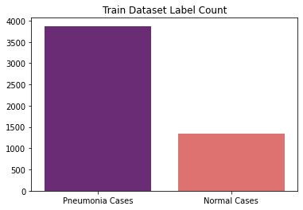

```
(3875, 1341)
```

```python
# distribution of train dataset
cnt = Counter()
for target in train_data.targets:
    cnt[target] += 1

normal_count = cnt[0]
pneumonia_count = cnt[1]

sns.barplot(x=['Pneumonia Cases', 'Normal Cases'],
            y=[pneumonia_count, normal_count], palette='magma')
plt.title('Train Dataset Label Count')
plt.show()
pneumonia_count, normal_count
```

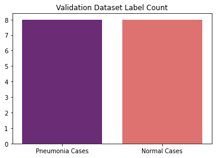

```
(8, 8)
```

```python
# distribution of validation dataset
cnt = Counter()
for target in valid_data.targets:
    cnt[target] += 1

normal_count = cnt[0]
pneumonia_count = cnt[1]

sns.barplot(x=['Pneumonia Cases', 'Normal Cases'],
            y=[pneumonia_count, normal_count], palette='magma')
plt.title('Validation Dataset Label Count')
plt.show()
pneumonia_count, normal_count
```

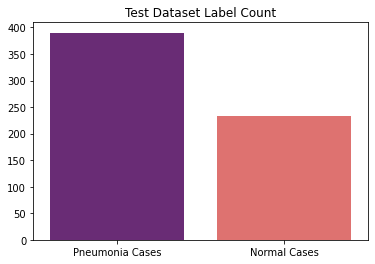

```
(390, 234)
```

```python
# distribution of test dataset
cnt = Counter()
for target in test_data.targets:
    cnt[target] += 1

normal_count = cnt[0]
pneumonia_count = cnt[1]

sns.barplot(x=['Pneumonia Cases', 'Normal Cases'],
            y=[pneumonia_count, normal_count], palette='magma')
plt.title('Test Dataset Label Count')
plt.show()
pneumonia_count, normal_count
```

We will have a look at the normal and pneumonia images of chest x-rays.

```python
num_classes = 2 # total classes of diagnosis (Normal, Pneumonia)
classes = ['NORMAL', 'PNEUMONIA']
```

```python
# un-normalize and display an image
def imshow(inp):
    """Imshow for Tensor."""
    inp = inp.numpy().transpose((1, 2, 0))
    mean = np.array([0.485, 0.456, 0.406])
    std = np.array([0.229, 0.224, 0.225])
    inp = std * inp + mean
    inp = np.clip(inp, 0, 1)
    plt.imshow(inp)
```

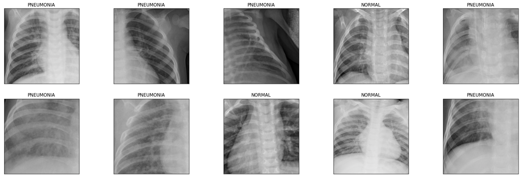

```python
# plot the images in the batch, along with predicted and true labels
fig = plt.figure(figsize=(25, 8))
for idx in np.arange(10):
    ax = fig.add_subplot(2, 10/2, idx+1, xticks=[], yticks=[])
    imshow(images.cpu()[idx])
    ax.set_title(classes[labels[idx]])
```

Let's create a CNN from scratch and check the test accuracy. Then we will try to improve the accuracy using transfer learning.

```python
# CNN architecture
class Net(nn.Module):

    def __init__(self):
        super(Net, self).__init__()

        ## cnn layers
        self.conv1 = nn.Conv2d(3, 32, 3, stride=2, padding=1)
        self.conv2 = nn.Conv2d(32, 64, 3, stride=2, padding=1)
        self.conv3 = nn.Conv2d(64, 128, 3, padding=1)

        # max-pool
        self.pool = nn.MaxPool2d(2, 2)

        # fully-connected
        self.fc1 = nn.Linear(7 * 7 * 128, 512)
        self.fc2 = nn.Linear(512, 512)
        self.fc3 = nn.Linear(512, num_classes)

        # drop-out
        self.dropout = nn.Dropout(0.3)

    def forward(self, x):

        x = F.relu(self.conv1(x))
        x = self.pool(x)
        x = F.relu(self.conv2(x))
        x = self.pool(x)
        x = F.relu(self.conv3(x))
        x = self.pool(x)

        # flatten the images with batch
        x = x.view(-1, 7 * 7 * 128)

        x = self.dropout(x)
        x = F.relu(self.fc1(x))

        x = self.dropout(x)
        x = F.relu(self.fc2(x))

        x = self.dropout(x)
        x = self.fc3(x)
        return x
```

```python
# instantiate the CNN
model_init = Net()
print(model_init)

# move tensors to GPU if CUDA is available
if use_cuda:
    model_init.cuda()
```

```
Net(
  (conv1): Conv2d(3, 32, kernel_size=(3, 3), stride=(2, 2), padding=(1, 1))
  (conv2): Conv2d(32, 64, kernel_size=(3, 3), stride=(2, 2), padding=(1, 1))
  (conv3): Conv2d(64, 128, kernel_size=(3, 3), stride=(1, 1), padding=(1, 1))
  (pool): MaxPool2d(kernel_size=2, stride=2, padding=0, dilation=1, ceil_mode=False)
  (fc1): Linear(in_features=6272, out_features=512, bias=True)
  (fc2): Linear(in_features=512, out_features=512, bias=True)
  (fc3): Linear(in_features=512, out_features=2, bias=True)
  (dropout): Dropout(p=0.3, inplace=False)
)
```

The first convolution layer will have a kernel size of 3 and stride 2, this will decrease the input image size by half. The second convolution layer will also have a kernel size of 3 and stride 2, which will decrease the input image size by half. The third convolution layer will have a kernel size of 3.

I have applied the max-pooling of stride 2 after each convolution layer to reduce the image size by half. I have also applied Relu activation for each of the convolution layers.

Then, I have flattened the inputs and applied a dropout layer with probability as 0.3. Three fully connected layers are applied with Relu activation and dropout 0.3 to produce the final output that will predict the classes of a chest x-ray.

```python
# define loss function criteria and optimizer
criterion_init = nn.CrossEntropyLoss()
optimizer_init = optim.Adam(model_init.parameters(), lr=0.03)
```

Let's define a function to train the model and save the final model parameters as 'model_init.pt'

```python
def train(n_epochs, train_loader, valid_loader, model, optimizer, criterion,
          use_cuda, save_path):

    valid_loss_min = np.Inf  # initialize inital loss to infinity
    train_loss_list = []
    valid_loss_list = []

    for epoch in range(1, n_epochs+1):
        epoch_start = datetime.utcnow()

        # initialize variables to monitor training and validation loss
        train_loss = 0.0
        valid_loss = 0.0

        # train the model
        model.train()
        for data, target in train_loader:

            # move to GPU
            if use_cuda:
                data, target = data.cuda(), target.cuda()

            # initialize weights to zero
            optimizer.zero_grad()

            # predict the output
            output = model(data)

            # calculate loss
            loss = criterion(output, target)

            # backpropogation
            loss.backward()

            # update gradients
            optimizer.step()

            train_loss += loss.item() * data.size(0)

        # validate the model
        model.eval()

        for data, target in valid_loader:

            if use_cuda:
                data, target = data.cuda(), target.cuda()

            output = model(data)
            loss = criterion(output, target)
            valid_loss = loss.item() * data.size(0)

        # calculate average losses
        train_loss = train_loss/len(train_loader.sampler)
        valid_loss = valid_loss/len(valid_loader.sampler)

        train_loss_list.append(train_loss)
        valid_loss_list.append(valid_loss)

        print('Epoch training time: {}'.format(datetime.utcnow() - epoch_start))
        print('Epoch: {} \tTraining Loss: {:.6f} \tValidation Loss: {:.6f}'.format(
            epoch, train_loss, valid_loss))

        # save the model if validation loss has decreased
        if valid_loss < valid_loss_min:
            torch.save(model.state_dict(), save_path)
            print('Model saved!\t\tValidation loss decreased ({:.6f} -> {:.6f})'.format(
                valid_loss_min, valid_loss))
            valid_loss_min = valid_loss

    # plot the training and validation loss
    plt.figure(figsize=(8, 8))
    plt.subplot(1, 2, 1)
    plt.plot(range(len(train_loss_list)), train_loss_list,
                label='Training Loss')
    plt.plot(range(len(valid_loss_list)), valid_loss_list,
                label='Validation Loss')
    plt.legend(loc='upper right')
    plt.xlabel('Number of epochs')
    plt.ylabel('Accuracy')
    plt.title('Training and Validation Loss')

    # return the trained model
    return model
```

```
Epoch training time: 0:01:23.119008
Epoch: 1 	Training Loss: 107.791887 	Validation Loss: 0.831046
Model saved!		Validation loss decreased (inf -> 0.831046)
Epoch training time: 0:01:23.460133
Epoch: 2 	Training Loss: 0.573463 	Validation Loss: 0.819986
Model saved!		Validation loss decreased (0.831046 -> 0.819986)
Epoch training time: 0:01:23.099130
Epoch: 3 	Training Loss: 0.571522 	Validation Loss: 0.831737
Epoch training time: 0:01:23.612106
Epoch: 4 	Training Loss: 0.571871 	Validation Loss: 0.802286
Model saved!		Validation loss decreased (0.819986 -> 0.802286)
Epoch training time: 0:01:23.600995
Epoch: 5 	Training Loss: 0.571734 	Validation Loss: 0.807024
Epoch training time: 0:01:24.110280
Epoch: 6 	Training Loss: 0.571187 	Validation Loss: 0.831803
Epoch training time: 0:01:22.953284
Epoch: 7 	Training Loss: 0.570627 	Validation Loss: 0.810372
Epoch training time: 0:01:23.075027
Epoch: 8 	Training Loss: 0.570779 	Validation Loss: 0.784867
Model saved!		Validation loss decreased (0.802286 -> 0.784867)
Epoch training time: 0:01:23.490744
Epoch: 9 	Training Loss: 0.570772 	Validation Loss: 0.818997
Epoch training time: 0:01:24.348842
Epoch: 10 	Training Loss: 0.570834 	Validation Loss: 0.843225
model_init training time: 0:13:54.968282
```

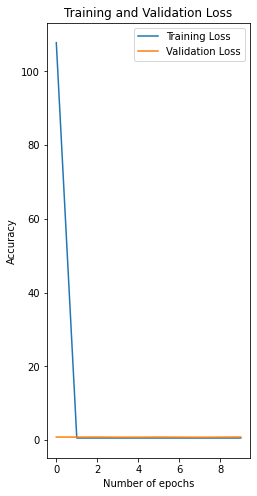

```python
# train the model
start = datetime.utcnow()
model_init = train(10, trainloader, validloader, model_init, optimizer_init,
                   criterion_init, use_cuda, 'model_init.pt')
print("model_init training time: {}".format(datetime.utcnow() - start))
```

```python
# load the model that got the best validation accuracy
model_init.load_state_dict(torch.load('model_init.pt'))
```

```
<All keys matched successfully>
```

```python
def test(test_loader, model, criterion, use_cuda):
    test_loss = 0.
    correct = 0.
    total = 0.

    for data, target in test_loader:
        # move to GPU
        if use_cuda:
            data, target = data.cuda(), target.cuda()
        # predict output
        output = model(data)
        # calculate the loss
        loss = criterion(output, target)
        # update average test loss
        test_loss += loss.item() * data.size(0)
        # convert output probabilities to predicted class
        pred = output.data.max(1, keepdim=True)[1]
        # compare predictions to true label
        correct += np.sum(np.squeeze(pred.eq(target.data.view_as(pred))).cpu().numpy())
        total += data.size(0)

    print('Test Loss: {:.6f}\n'.format(test_loss/len(testloader.sampler)))
    print('\nTest Accuracy: %2d%% (%2d/%2d)' %
          (100. * correct / total, correct, total))
```

```python
# test the model
test(testloader, model_init, criterion_init, use_cuda)
```

```
Test Loss: 0.676148


Test Accuracy: 62% (390/624)
```

```python
# visualize the confusion matrix
def plot_confusion_matrix(C):
    plt.figure(figsize=(20, 4))
    labels = [0, 1]
    cmap=sns.light_palette("blue")
    plt.subplot(1, 3, 1)
    sns.heatmap(C, annot=True, cmap=cmap, fmt=".0f",
                xticklabels=labels, yticklabels=labels)
    plt.xlabel('Predicted Class')
    plt.ylabel('Original Class')
    plt.title("Confusion matrix")
```

```python
# generate confustion matrix
confusion_matrix = torch.zeros(num_classes, num_classes)
with torch.no_grad():
    for i, (inputs, labels) in enumerate(testloader):
        if use_cuda:
            inputs = inputs.cuda()
            labels = labels.cuda()
        outputs = model_init(inputs)
        _, preds = torch.max(outputs, 1)
        for t, p in zip(labels.view(-1), preds.view(-1)):
                confusion_matrix[t.long(), p.long()] += 1

print(confusion_matrix)
```

```
tensor([[  0., 234.],
        [  0., 390.]])
```

```python
# get the per-class accuracy
print(confusion_matrix.diag()/confusion_matrix.sum(1))
```

```
tensor([0., 1.])
```

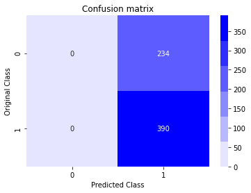

```python
# plot the confustion matrix
plot_confusion_matrix(confusion_matrix)
```

Now, we will use transfer learning to create a CNN that can diagnose pneumonia from images.

```python
# download the pretraibed DenseNet-169 model
model = models.densenet169(pretrained=True)
```

```
Downloading: "https://download.pytorch.org/models/densenet169-b2777c0a.pth" to /root/.cache/torch/checkpoints/densenet169-b2777c0a.pth
```

```python
# freeze the model parameters
for param in model.parameters():
    param.requires_grad = False
```

```python
# check the number of input and output features
model.classifier
```

```
Linear(in_features=1664, out_features=1000, bias=True)
```

We will keep the number of input features same, however we will change the number of output features to 2 as we want to predict only two classes i.e. Normal and Pneumonia.

```python
# update the out_features for model
model.classifier = nn.Linear(model.classifier.in_features, num_classes)
```

```python
fc_parameters = model.classifier.parameters()
```

```python
for param in fc_parameters:
    param.requires_grad = True
```

```python
# move model to gpu
if use_cuda:
    model = model.cuda()
```

```python
# DenseNet-169 model architecture
model
```

```
DenseNet(
  (features): Sequential(
    (conv0): Conv2d(3, 64, kernel_size=(7, 7), stride=(2, 2), padding=(3, 3), bias=False)
    (norm0): BatchNorm2d(64, eps=1e-05, momentum=0.1, affine=True, track_running_stats=True)
    (relu0): ReLU(inplace=True)
    (pool0): MaxPool2d(kernel_size=3, stride=2, padding=1, dilation=1, ceil_mode=False)
    (denseblock1): _DenseBlock(
      (denselayer1): _DenseLayer(
        (norm1): BatchNorm2d(64, eps=1e-05, momentum=0.1, affine=True, track_running_stats=True)
        (relu1): ReLU(inplace=True)
        (conv1): Conv2d(64, 128, kernel_size=(1, 1), stride=(1, 1), bias=False)
        (norm2): BatchNorm2d(128, eps=1e-05, momentum=0.1, affine=True, track_running_stats=True)
        (relu2): ReLU(inplace=True)
        (conv2): Conv2d(128, 32, kernel_size=(3, 3), stride=(1, 1), padding=(1, 1), bias=False)
      )
      (denselayer2): _DenseLayer(
        (norm1): BatchNorm2d(96, eps=1e-05, momentum=0.1, affine=True, track_running_stats=True)
        (relu1): ReLU(inplace=True)
        (conv1): Conv2d(96, 128, kernel_size=(1, 1), stride=(1, 1), bias=False)
        (norm2): BatchNorm2d(128, eps=1e-05, momentum=0.1, affine=True, track_running_stats=True)
        (relu2): ReLU(inplace=True)
        (conv2): Conv2d(128, 32, kernel_size=(3, 3), stride=(1, 1), padding=(1, 1), bias=False)
      )
      (denselayer3): _DenseLayer(
        (norm1): BatchNorm2d(128, eps=1e-05, momentum=0.1, affine=True, track_running_stats=True)
        (relu1): ReLU(inplace=True)
        (conv1): Conv2d(128, 128, kernel_size=(1, 1), stride=(1, 1), bias=False)
        (norm2): BatchNorm2d(128, eps=1e-05, momentum=0.1, affine=True, track_running_stats=True)
        (relu2): ReLU(inplace=True)
        (conv2): Conv2d(128, 32, kernel_size=(3, 3), stride=(1, 1), padding=(1, 1), bias=False)
      )
      (denselayer4): _DenseLayer(
        (norm1): BatchNorm2d(160, eps=1e-05, momentum=0.1, affine=True, track_running_stats=True)
        (relu1): ReLU(inplace=True)
        (conv1): Conv2d(160, 128, kernel_size=(1, 1), stride=(1, 1), bias=False)
        (norm2): BatchNorm2d(128, eps=1e-05, momentum=0.1, affine=True, track_running_stats=True)
        (relu2): ReLU(inplace=True)
        (conv2): Conv2d(128, 32, kernel_size=(3, 3), stride=(1, 1), padding=(1, 1), bias=False)
      )
      (denselayer5): _DenseLayer(
```

[output cut: 637 more lines]

```
        (conv2): Conv2d(128, 32, kernel_size=(3, 3), stride=(1, 1), padding=(1, 1), bias=False)
      )
      (denselayer32): _DenseLayer(
        (norm1): BatchNorm2d(1632, eps=1e-05, momentum=0.1, affine=True, track_running_stats=True)
        (relu1): ReLU(inplace=True)
        (conv1): Conv2d(1632, 128, kernel_size=(1, 1), stride=(1, 1), bias=False)
        (norm2): BatchNorm2d(128, eps=1e-05, momentum=0.1, affine=True, track_running_stats=True)
        (relu2): ReLU(inplace=True)
        (conv2): Conv2d(128, 32, kernel_size=(3, 3), stride=(1, 1), padding=(1, 1), bias=False)
      )
    )
    (norm5): BatchNorm2d(1664, eps=1e-05, momentum=0.1, affine=True, track_running_stats=True)
  )
  (classifier): Linear(in_features=1664, out_features=2, bias=True)
)
```

```python
# define the loss function and optimizer
criterion = nn.CrossEntropyLoss()
optimizer = optim.Adam(model.classifier.parameters(), lr=0.001)
```

We will use the same function to train the model and save the final model parameters as 'model.pt'

```
Epoch training time: 0:02:07.862004
Epoch: 1 	Training Loss: 0.336447 	Validation Loss: 0.665434
Model saved!		Validation loss decreased (inf -> 0.665434)
Epoch training time: 0:02:07.297317
Epoch: 2 	Training Loss: 0.235003 	Validation Loss: 0.812540
Epoch training time: 0:02:07.148375
Epoch: 3 	Training Loss: 0.241158 	Validation Loss: 0.625733
Model saved!		Validation loss decreased (0.665434 -> 0.625733)
Epoch training time: 0:02:06.895096
Epoch: 4 	Training Loss: 0.222347 	Validation Loss: 1.039106
Epoch training time: 0:02:05.589865
Epoch: 5 	Training Loss: 0.226882 	Validation Loss: 0.939040
Epoch training time: 0:02:05.756665
Epoch: 6 	Training Loss: 0.236689 	Validation Loss: 0.831222
Epoch training time: 0:02:05.437880
Epoch: 7 	Training Loss: 0.211330 	Validation Loss: 0.875436
Epoch training time: 0:02:06.640969
Epoch: 8 	Training Loss: 0.209414 	Validation Loss: 0.619645
Model saved!		Validation loss decreased (0.625733 -> 0.619645)
Epoch training time: 0:02:07.906568
Epoch: 9 	Training Loss: 0.209592 	Validation Loss: 0.569257
Model saved!		Validation loss decreased (0.619645 -> 0.569257)
Epoch training time: 0:02:06.510524
Epoch: 10 	Training Loss: 0.213758 	Validation Loss: 0.695274
Epoch training time: 0:02:04.844941
Epoch: 11 	Training Loss: 0.200334 	Validation Loss: 0.759424
Epoch training time: 0:02:04.394095
Epoch: 12 	Training Loss: 0.205159 	Validation Loss: 0.868648
Epoch training time: 0:02:04.557117
Epoch: 13 	Training Loss: 0.199599 	Validation Loss: 1.010332
Epoch training time: 0:02:04.999312
Epoch: 14 	Training Loss: 0.196574 	Validation Loss: 0.978211
Epoch training time: 0:02:09.648708
Epoch: 15 	Training Loss: 0.191889 	Validation Loss: 0.719485
Epoch training time: 0:02:06.475597
Epoch: 16 	Training Loss: 0.194249 	Validation Loss: 0.718118
Epoch training time: 0:02:10.322440
Epoch: 17 	Training Loss: 0.197834 	Validation Loss: 0.972994
Epoch training time: 0:02:10.313834
Epoch: 18 	Training Loss: 0.205702 	Validation Loss: 0.704382
```

[output cut: 11 more lines]

```
Epoch: 24 	Training Loss: 0.197661 	Validation Loss: 0.569405
Epoch training time: 0:02:06.034270
Epoch: 25 	Training Loss: 0.193476 	Validation Loss: 1.152341
Epoch training time: 0:02:05.503330
Epoch: 26 	Training Loss: 0.196449 	Validation Loss: 0.804347
Epoch training time: 0:02:05.116862
Epoch: 27 	Training Loss: 0.193370 	Validation Loss: 0.904101
Epoch training time: 0:02:05.202886
Epoch: 28 	Training Loss: 0.202851 	Validation Loss: 0.533598
Model saved!		Validation loss decreased (0.569257 -> 0.533598)
Epoch training time: 0:02:05.137678
Epoch: 29 	Training Loss: 0.205733 	Validation Loss: 0.781455
Epoch training time: 0:02:05.863032
Epoch: 30 	Training Loss: 0.196579 	Validation Loss: 0.795180
model training time: 1:03:27.896798
```

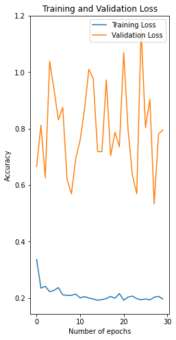

```python
# train the model
start = datetime.utcnow()
model = train(30, trainloader, validloader, model, optimizer,
                   criterion, use_cuda, 'model.pt')
print("model training time: {}".format(datetime.utcnow() - start))
```

```python
# load the model that got the best validation accuracy
model.load_state_dict(torch.load('model.pt'))
```

```
<All keys matched successfully>
```

```python
# test the model
test(testloader, model, criterion, use_cuda)
```

```
Test Loss: 0.295649


Test Accuracy: 90% (564/624)
```

Let's try to visualize the predict the final output of few a few xray images.

[figure not shown]

```python
dataiter = iter(testloader)
images, labels = dataiter.next()
images.numpy()

if use_cuda:
    images = images.cuda()

# get sample outputs
output = model(images)
# convert output probabilities to predicted class
_, preds_tensor = torch.max(output, 1)

if use_cuda:
    preds = np.squeeze(preds_tensor.cpu().numpy())
else:
    preds = np.squeeze(preds_tensor.numpy())

# plot the images in the batch, along with predicted and true labels
fig = plt.figure(figsize=(25, 8))
for idx in np.arange(10):
    ax = fig.add_subplot(2, 10/2, idx+1, xticks=[], yticks=[])
    imshow(images.cpu()[idx])
    ax.set_title("{} ({})".format(classes[preds[idx]], classes[labels[idx]]),
                 color=("green" if preds[idx] == labels[idx].item() else "red"))
```

```python
# generate confustion matrix
confusion_matrix = torch.zeros(num_classes, num_classes)
with torch.no_grad():
    for i, (inputs, labels) in enumerate(testloader):
        if use_cuda:
            inputs = inputs.cuda()
            labels = labels.cuda()
        outputs = model(inputs)
        _, preds = torch.max(outputs, 1)
        for t, p in zip(labels.view(-1), preds.view(-1)):
                confusion_matrix[t.long(), p.long()] += 1

print(confusion_matrix)
```

```
tensor([[199.,  35.],
        [ 25., 365.]])
```

```python
# get the per-class accuracy
print(confusion_matrix.diag()/confusion_matrix.sum(1))
```

```
tensor([0.8504, 0.9359])
```

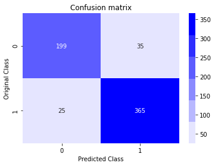

```python
# plot the confusion matrix
plot_confusion_matrix(confusion_matrix)
```